# L5_Times

# Exploratory analysis

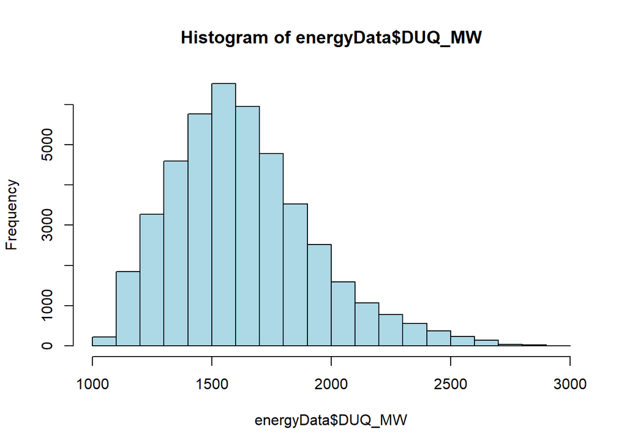

```r
hist(energyData$DUQ_MW, col="lightblue")
```

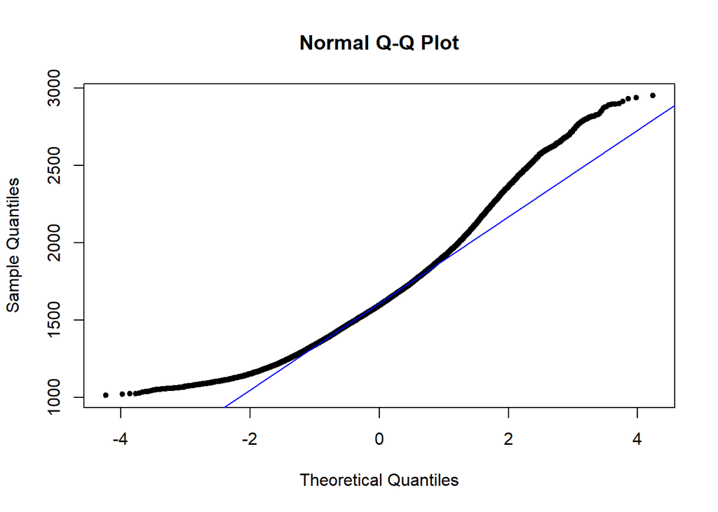

```r
qqnorm(energyData$DUQ_MW, pch=20); qqline(energyData$DUQ_MW, col="blue")
```

The data displayed in the following figure is supposed to be non-independent and the TS has discrete time intervals.

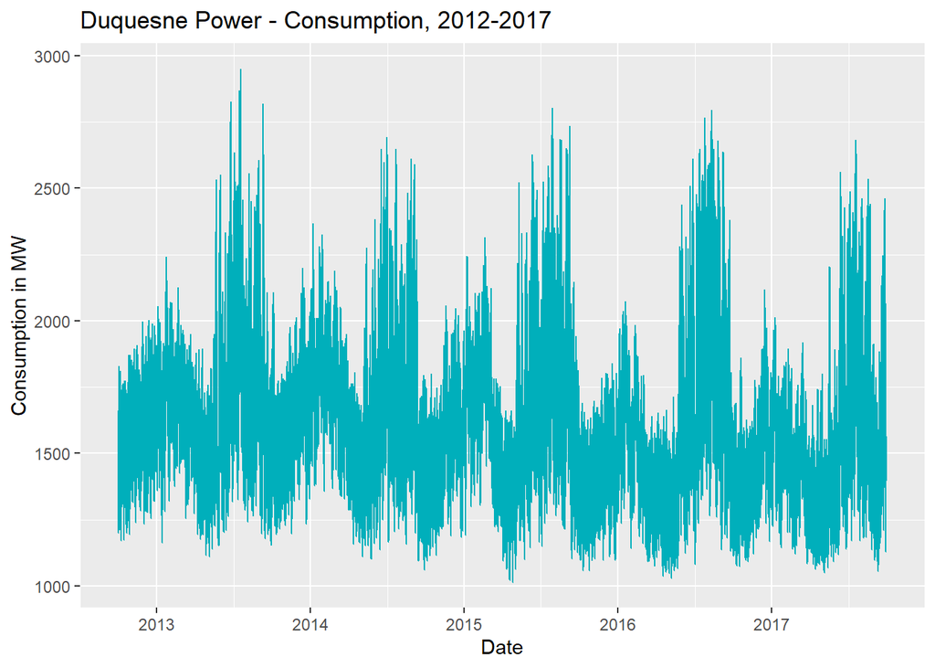

```r
ggplot(data = energyData, aes(x = Datetime, y = DUQ_MW))+
  geom_line(color = "#00AFBB", size = 0.5) + ggtitle('Duquesne Power - Consumption, 2012-2017')+
  xlab('Date') + ylab('Consumption in MW')
```

## Yearly

Examine the specific year for better understanding of seasonality.

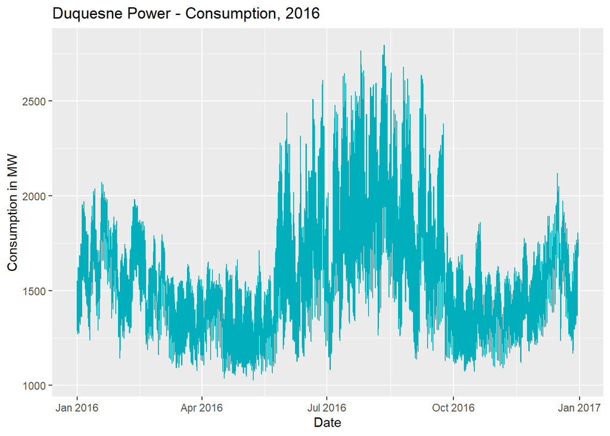

```r
ggplot(data = energyData[energyData$Datetime >= '2016-01-01' & energyData$Datetime <= '2016-12-31',], aes(x = Datetime, y = DUQ_MW))+
  geom_line(color = "#00AFBB", size = 0.5) + ggtitle('Duquesne Power - Consumption, 2016')+
  xlab('Date') + ylab('Consumption in MW')
```

## Monthly

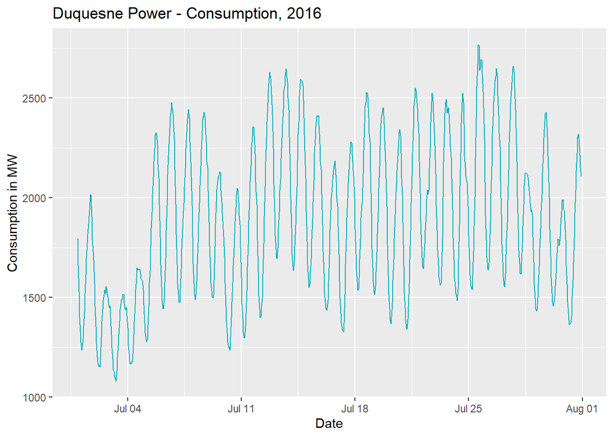

```r
ggplot(data = energyData[energyData$Datetime >= '2016-07-01' & energyData$Datetime <= '2016-08-01',], aes(x = Datetime, y = DUQ_MW))+
  geom_line(color = "#00AFBB", size = 0.5) + ggtitle('Duquesne Power - Consumption, 2016')+
  xlab('Date') + ylab('Consumption in MW')
```

## Weekly

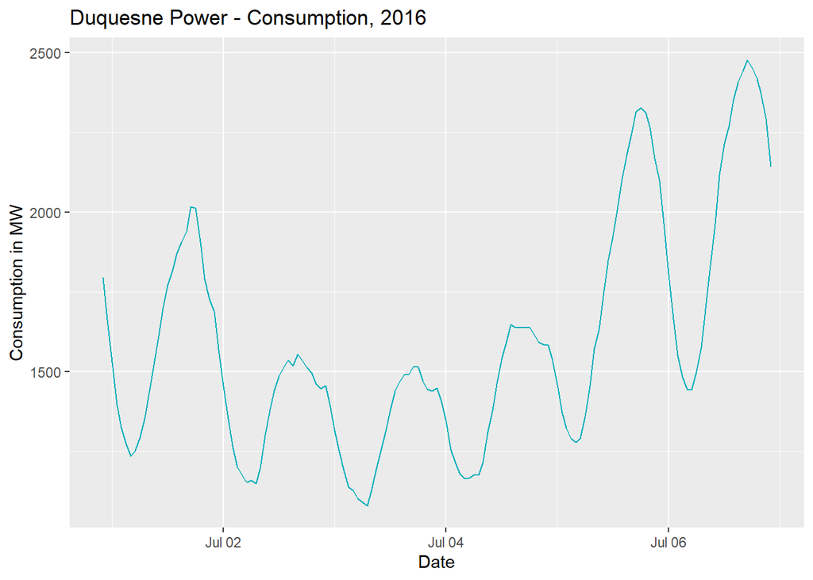

```r
ggplot(data = energyData[energyData$Datetime >= '2016-07-01' & energyData$Datetime <= '2016-07-07',], aes(x = Datetime, y = DUQ_MW))+
  geom_line(color = "#00AFBB", size = 0.5) + ggtitle('Duquesne Power - Consumption, 2016')+
  xlab('Date') + ylab('Consumption in MW')
```

## Daily

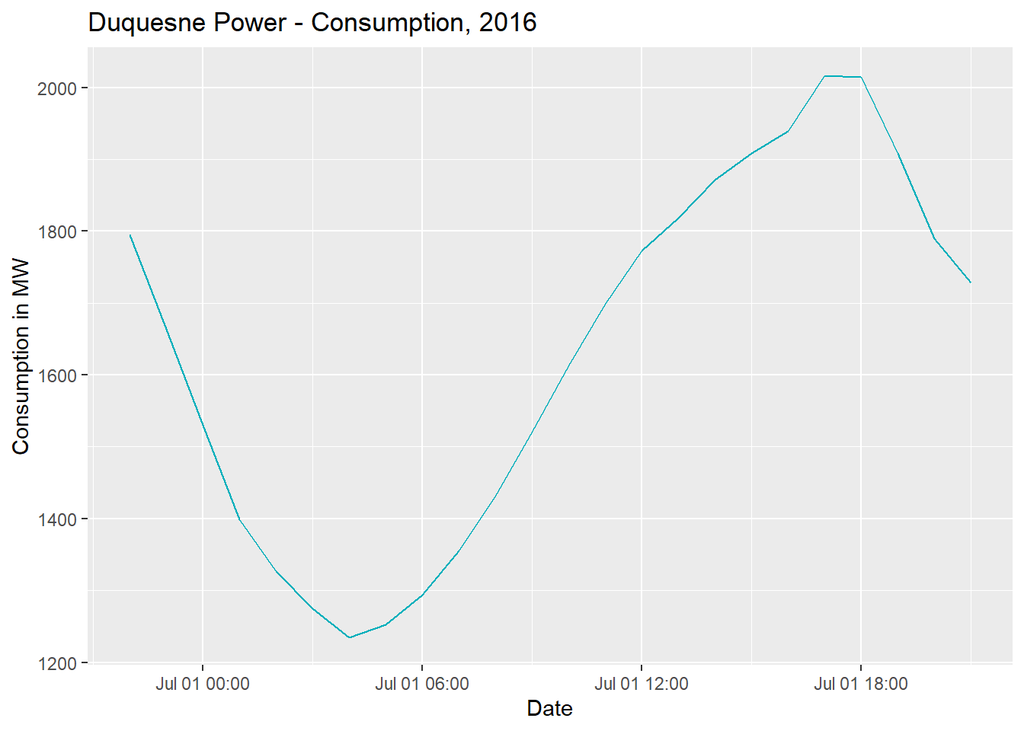

```r
ggplot(data = energyData[energyData$Datetime >= '2016-07-01 00:00:00' & energyData$Datetime <= '2016-07-01 23:00:00',], aes(x = Datetime, y = DUQ_MW))+
  geom_line(color = "#00AFBB", size = 0.5) + ggtitle('Duquesne Power - Consumption, 2016')+
  xlab('Date') + ylab('Consumption in MW')
```

# Simple moving average

Smoothing is a way to locally aggregate data where non-systematic components compensate each other.

$$\begin{aligned}\large
Y_t=\frac{1}{2k+1}\sum_{j=-k}^k{X_{t+j}}
\end{aligned}$$

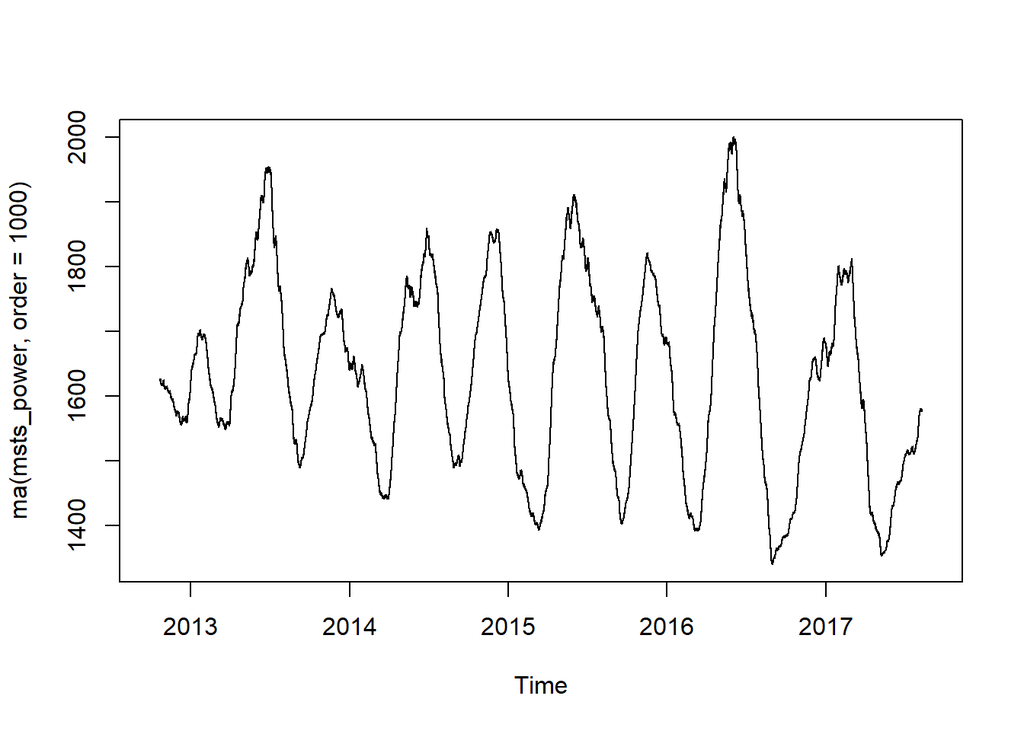

```r
plot(ma(msts_power, order=1000))
```

# TS decomposition

Given the additive TS model

$$\begin{aligned}\large
X_t = T_t+Z_t +S_t+\epsilon_t,t=1,..,n
\end{aligned}$$
we may decompose the TS into the four components: trend, cycle, seasonalty and error(white noise).

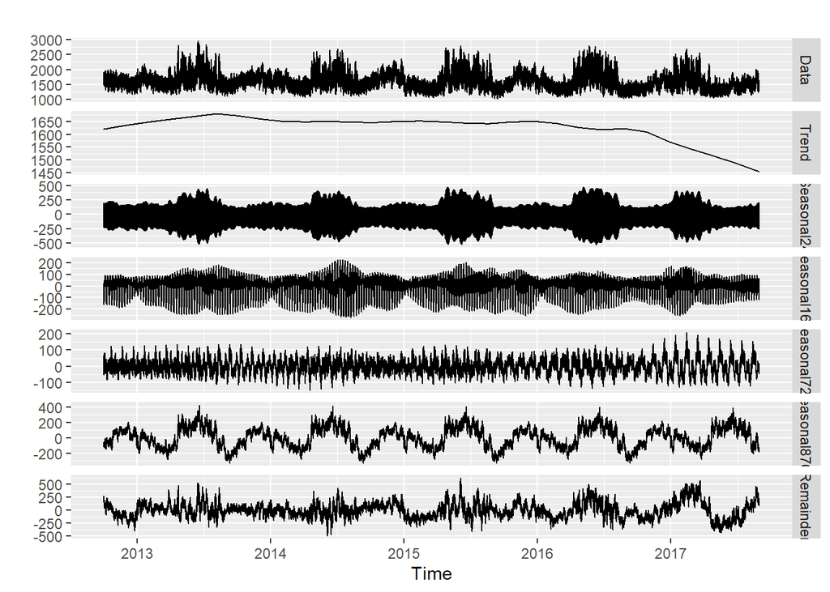

```r
mstl(msts_power2) %>% autoplot()
```

$$\begin{aligned}\large
\tilde{S_t} = \tilde{X_t}-\tilde{T_t}
\end{aligned}$$

# ACF and PACF

$$\begin{aligned}\large
\rho(k) = \frac{\gamma(k)}{\gamma(0)},k=0,1,..
\end{aligned}$$

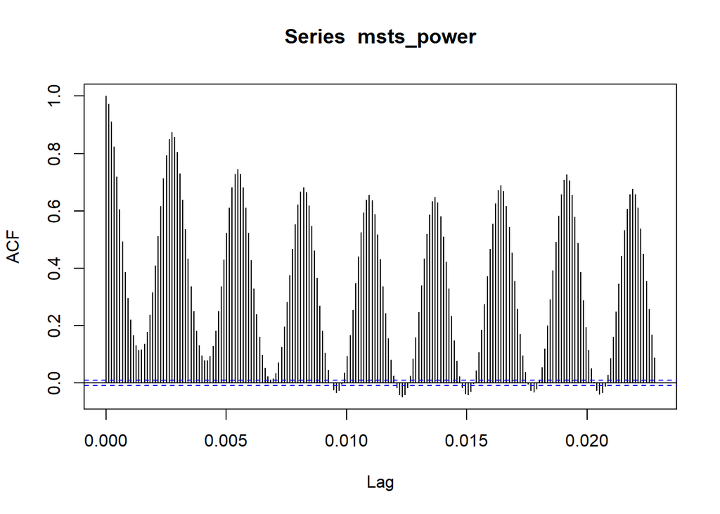

```r
acf(msts_power, lag.max = 200)
```

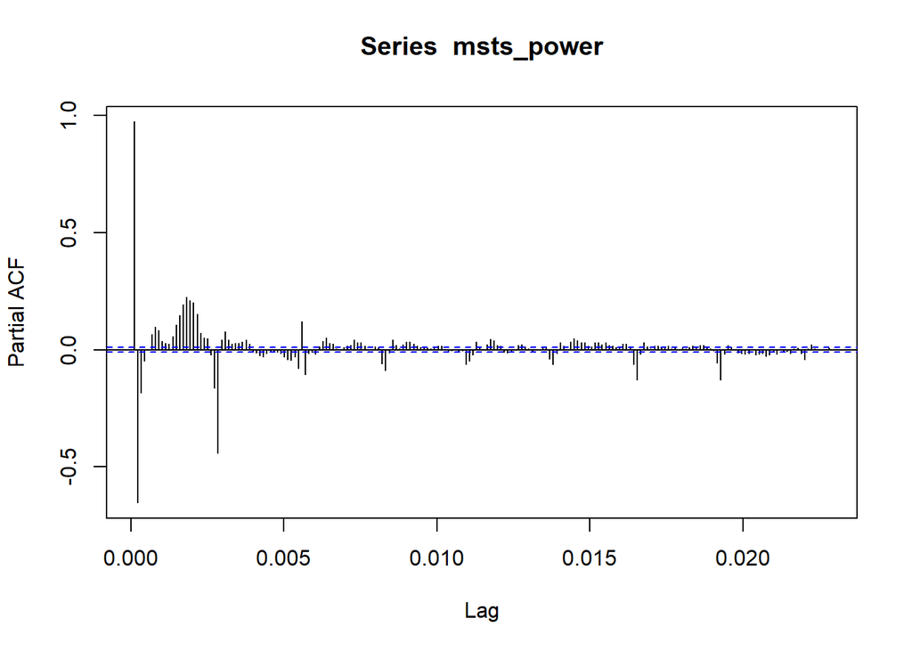

```r
pacf(msts_power, lag.max = 200)
```

# Stationarity

Strong stationarity is defined as follows:
$$\begin{aligned}\large
X(t_i) \simeq X(t_i+ \tau)
\end{aligned}$$
$$\begin{aligned}\large
H_0:\ \gamma \neq 0
\end{aligned}$$

```r
adf.test(msts_power, alternative = "stationary")
```

```
##
##  Augmented Dickey-Fuller Test
##
## data:  msts_power
## Dickey-Fuller = -10.856, Lag order = 35, p-value = 0.01
## alternative hypothesis: stationary
```

The TS is stationary, though the ACF plot implies the majority of observations exceeds the boundaries of the significance interval.

# Simple exponential smoothing

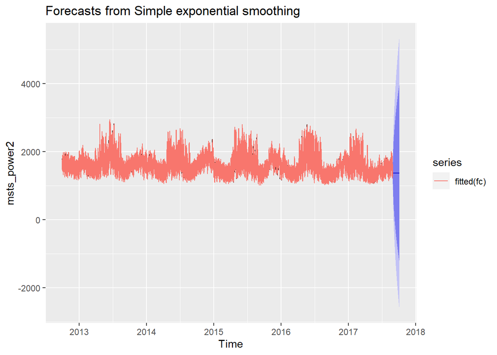

```r
fc <- ses(msts_power2, h=24*36)
autoplot(fc) + autolayer(fitted(fc))
```

```r
accuracy(fc$fitted, duq_test$DUQ_MW)
```

```
##                 ME     RMSE      MAE       MPE     MAPE
## Test set -97.51936 313.6078 258.4307 -9.509817 17.61876
```

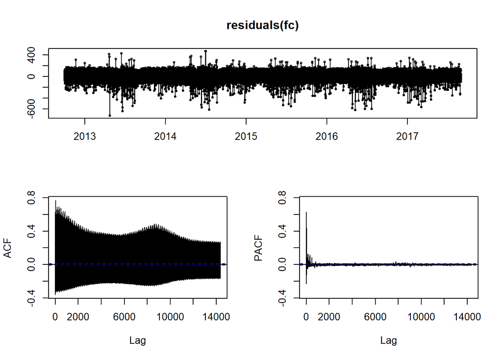

```r
tsdisplay(residuals(fc))
```

# ARFIMA

In an ARIMA model, the integrated part of the model includes the differencing operator (1 − B) (where B is the backshift operator) raised to an integer power. In a fractional model, the power is allowed to be fractional, with the meaning of the term identified using the following formal binomial series expansion
$$\begin{aligned}\large
(1-B)^d=\sum_{k=0}^{\propto}C_d^k(-B)^k
\end{aligned}$$

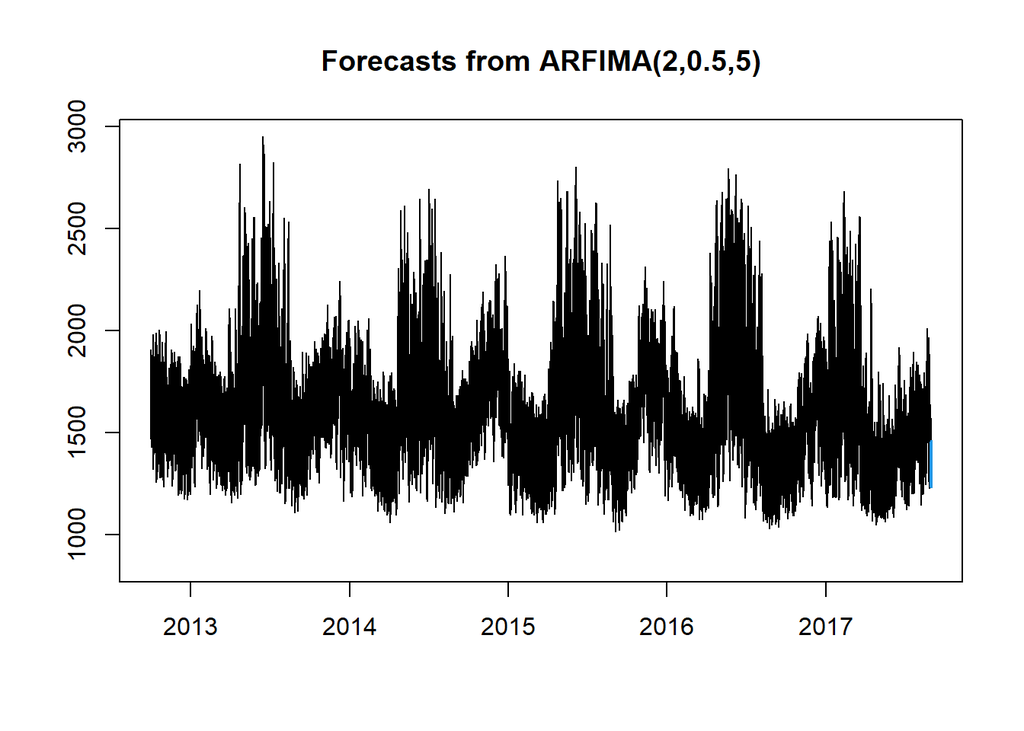

```r
fitarfima <- arfima(msts_power2)
plot(forecast(fitarfima))
```

```r
accuracy(fitarfima$fitted,duq_test$DUQ_MW)
```

```
##                 ME     RMSE      MAE       MPE     MAPE
## Test set -97.31979 306.3955 247.7103 -9.326757 16.77583
```

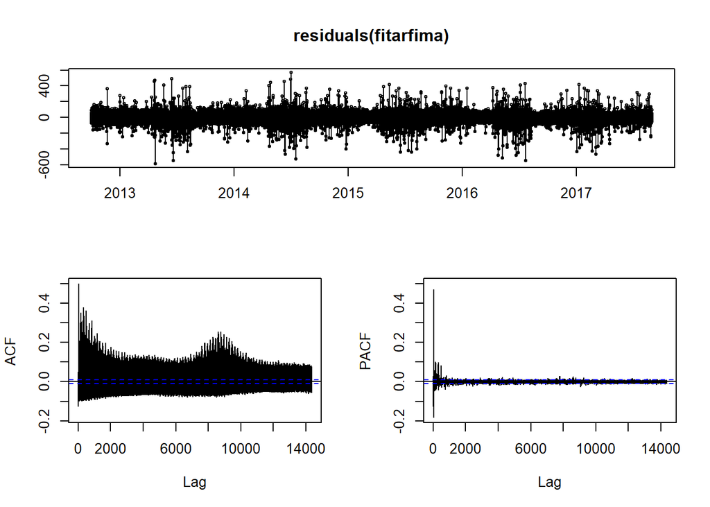

```r
tsdisplay(residuals(fitarfima))
```

# LOESS(Local polynomial regression)

Forecasts of STL objects are obtained by applying a non-seasonal forecasting method to the seasonally adjusted data and re-seasonalizing using the last year of the seasonal component.

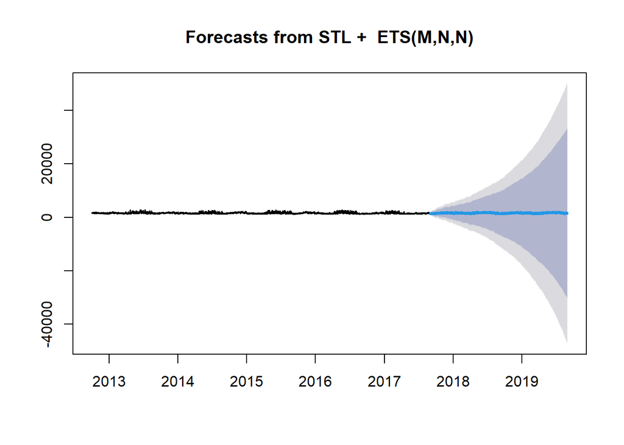

```r
lpr_fit <- stlf(msts_power)
plot(forecast(lpr_fit))
```

```r
accuracy(lpr_fit$fitted,duq_test$DUQ_MW)
```

```
##                 ME     RMSE      MAE       MPE     MAPE
## Test set -97.61584 296.7804 240.7237 -9.279443 16.34963
```

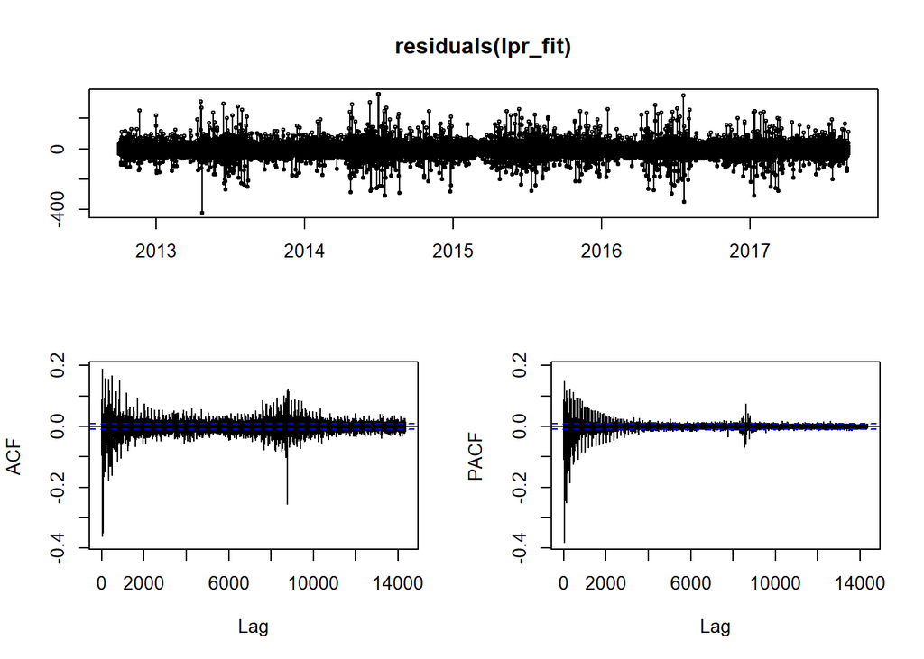

```r
tsdisplay(residuals(lpr_fit))
```